# IODS-Final

# The regression model

The only reason that I wanted to show this regression model is that it gives a clear view of the data and also an idea how the high correlation might affect the analysis in the future.

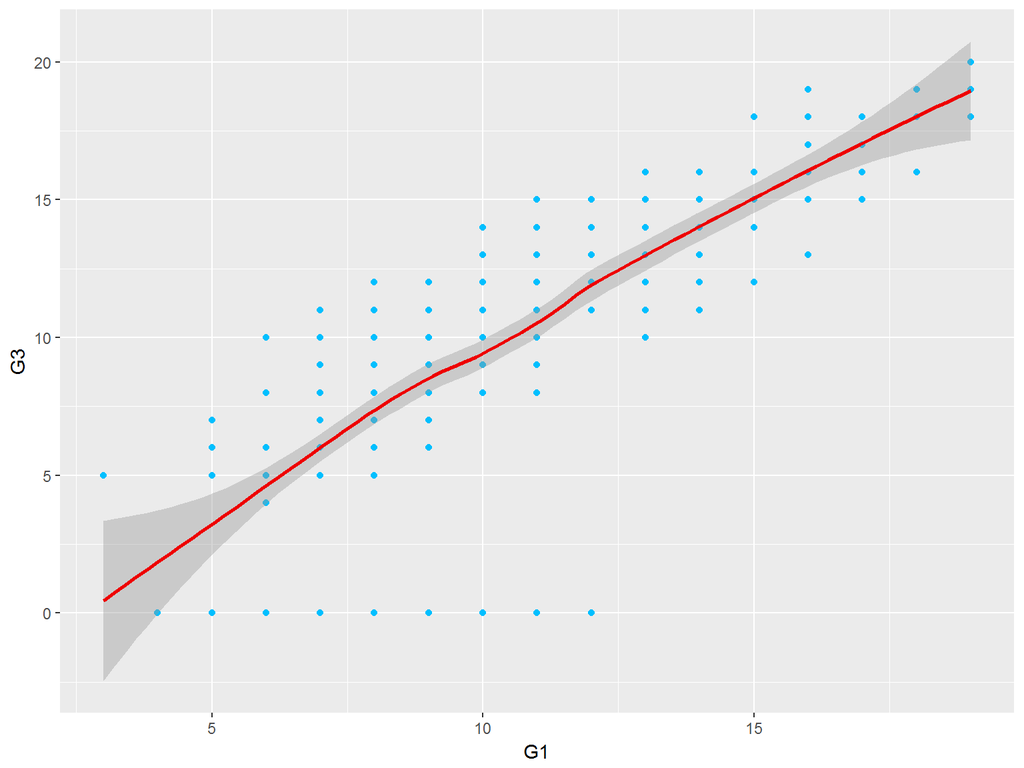

```r
p2 <- ggplot(alcdata_, aes(x=G1, y= G3)) + geom_point(col="deepskyblue1") + geom_smooth( col = "red2")

p2
```

The plot already shows how much the zero values affect the regression. I thought about taking the away but then the results would’ve been biased upwards.

```r
model5 <- lm(G1 ~ G3, alcdata_)
summary(model5)
```

```
##
## Call:
## lm(formula = G1 ~ G3, data = alcdata_)
##
## Residuals:
##     Min      1Q  Median      3Q     Max
## -4.7619 -1.4878 -0.0631  1.3037  7.1145
##
## Coefficients:
##             Estimate Std. Error t value Pr(>|t|)
## (Intercept)  4.88550    0.24769   19.72   <2e-16 ***
## G3           0.57529    0.02174   26.46   <2e-16 ***
## ---
## Signif. codes:  0 '***' 0.001 '**' 0.01 '*' 0.05 '.' 0.1 ' ' 1
##
## Residual standard error: 1.989 on 380 degrees of freedom
## Multiple R-squared:  0.6482, Adjusted R-squared:  0.6473
## F-statistic: 700.3 on 1 and 380 DF,  p-value: < 2.2e-16
```

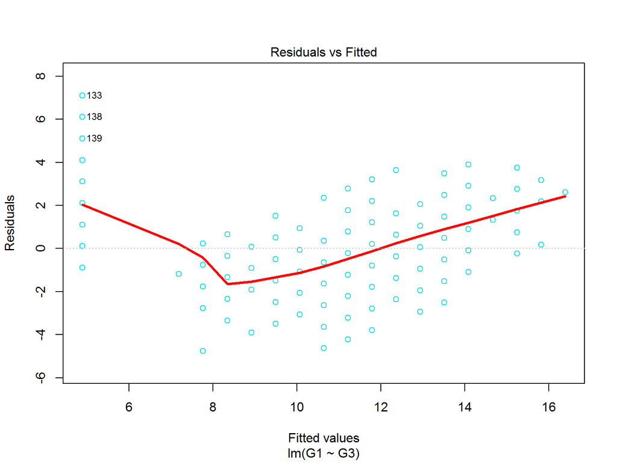

```r
plot(model5,  which=c(1), col = "turquoise2",  lwd = 3)
```

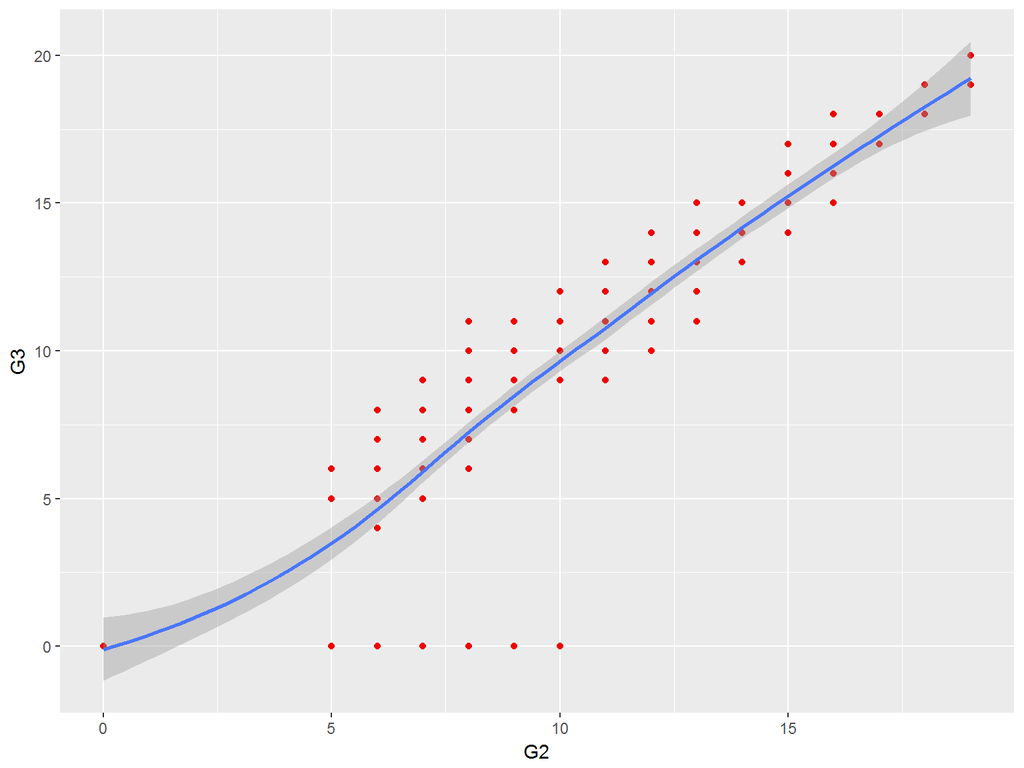

```r
p3 <- ggplot(alcdata_, aes(x=G2, y= G3)) + geom_point(col="red2") + geom_smooth(col = "royalblue1")

p3
```

The same thing happens here that also happened in the first regression model: the zero values affect a lot. These pictures also show well how correlated the variables are. This might be a trouble in the future but we there isn’t much to do a this point. After all the results are done then we can figure out if the model would be better with other variables that might have explanation power.

```r
model6 <- lm(G2 ~ G3, alcdata_)
summary(model6)
```

```
##
## Call:
## lm(formula = G2 ~ G3, data = alcdata_)
##
## Residuals:
##     Min      1Q  Median      3Q     Max
## -3.1643 -0.9492 -0.1178  0.8357  6.9577
##
## Coefficients:
##             Estimate Std. Error t value Pr(>|t|)
## (Intercept)  3.04230    0.20530   14.82   <2e-16 ***
## G3           0.73837    0.01802   40.98   <2e-16 ***
## ---
## Signif. codes:  0 '***' 0.001 '**' 0.01 '*' 0.05 '.' 0.1 ' ' 1
##
## Residual standard error: 1.649 on 380 degrees of freedom
## Multiple R-squared:  0.8155, Adjusted R-squared:  0.815
## F-statistic:  1679 on 1 and 380 DF,  p-value: < 2.2e-16
```

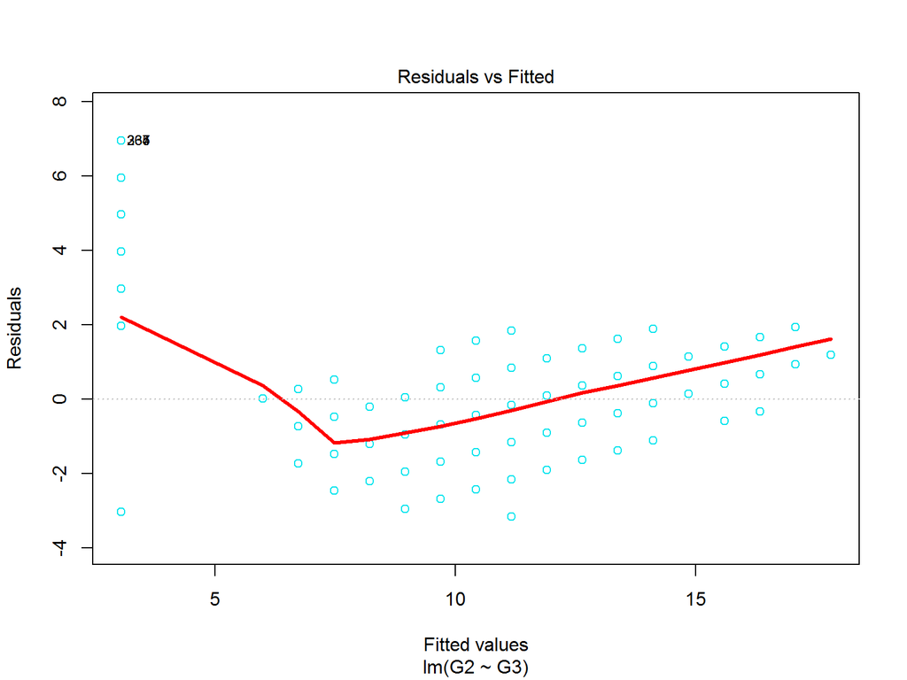

```r
plot(model6,  which=c(1), col = "turquoise2",  lwd = 3)
```

# The clustering model

In clustering the idea is that some of the observations are closer to each other compared to the others. This means that the data is in a way clustered and the idea is to try to find these clusters.

It is quite simple to find clusters but I want to optimize the amount of clusters which I do below after first clustering with 10 clusters. After this we try to analyse what happens when there is new observations. Could we classify them also?

First we scale the data so that all the means are zero.

```r
alcdata_scaled <- scale(alcdata_)
summary(alcdata_scaled)
```

```
##        G1                G2                 G3
##  Min.   :-2.3472   Min.   :-2.79501   Min.   :-2.2161
##  1st Qu.:-0.8543   1st Qu.:-0.64240   1st Qu.:-0.5093
##  Median :-0.1079   Median : 0.07513   Median : 0.1307
##  Mean   : 0.0000   Mean   : 0.00000   Mean   : 0.0000
##  3rd Qu.: 0.6386   3rd Qu.: 0.59698   3rd Qu.: 0.7707
##  Max.   : 2.4301   Max.   : 2.16251   Max.   : 2.0508
```

```r
alcdata_scaled <- as.data.frame(alcdata_scaled)
```

Then we make 4 groups for the variables. The groups are the following: low, med_low, med_high and high. This is because in clustering the point is to group different observations.

# G1

```r
cutoffs <- quantile(alcdata_scaled$G1)

labels <- c("low", "med_low", "med_high", "high")

G1_category <- cut(alcdata_scaled$G1, breaks = cutoffs, include.lowest = TRUE, label = labels)

table(G1_category)
```

```
## G1_category
##      low  med_low med_high     high
##      110       81      100       91
```

# G2

```r
cutoffs <- quantile(alcdata_scaled$G2)

labels <- c("low", "med_low", "med_high", "high")

G2_category <- cut(alcdata_scaled$G2, breaks = cutoffs, include.lowest = TRUE, label = labels)

table(G2_category)
```

```
## G2_category
##      low  med_low med_high     high
##       96      124       72       90
```

# G3

```r
cutoffs <- quantile(alcdata_scaled$G3)

labels <- c("low", "med_low", "med_high", "high")

G3_category <- cut(alcdata_scaled$G3, breaks = cutoffs, include.lowest = TRUE, label = labels)

table(G3_category)
```

```
## G3_category
##      low  med_low med_high     high
##      100      126       82       74
```

Now we drop the old G3 variable from the dataset. Then we divide the dataset to train and test sets, so that 80% of the data belongs to the train set.

```r
alcdata_scaled <- dplyr::select(alcdata_scaled, -G3)
alcdata_scaled <- data.frame(alcdata_scaled, G3_category)
str(alcdata_scaled)
```

```
## 'data.frame':    382 obs. of  3 variables:
##  $ G1         : num  -1.75 -1.75 -1.15 1.24 -1.45 ...
##  $ G2         : num  -1.229 -1.49 -0.708 0.858 -0.186 ...
##  $ G3_category: Factor w/ 4 levels "low","med_low",..: 1 1 2 4 2 4 2 1 4 4 ...
```

```r
n <- nrow(alcdata_scaled)
eighty_perc <- sample(n, size = n * 0.8)
train <- alcdata_scaled[eighty_perc,]
test <- alcdata_scaled[-eighty_perc,]
```

Now we fit the linear discriminant analysis on the train set. We use the categorical G3 as the target variable and all the other variables (G1 and G2) in the dataset as predictor variables. This gives us an idea how G3 also known as the final grade interacts with the other variables.

```r
lda.fit <- lda(G3_category ~ ., data = train)
lda.fit
```

```
## Call:
## lda(G3_category ~ ., data = train)
##
## Prior probabilities of groups:
##       low   med_low  med_high      high
## 0.2426230 0.3377049 0.2196721 0.2000000
##
## Group means:
##                  G1         G2
## low      -1.1004470 -1.2083205
## med_low  -0.2513577 -0.1705882
## med_high  0.4781577  0.5385637
## high      1.3581226  1.3241393
##
## Coefficients of linear discriminants:
##         LD1       LD2
## G1 1.000717  1.964567
## G2 1.528494 -1.906981
##
## Proportion of trace:
##    LD1    LD2
## 0.9959 0.0041
```